# Proyecto Fin de Master

Lucía Rico Cuéllar

08 de julio de 2017

Vamos a usar los datos de series mensuales de tráfico en autopistas estatales de peaje, proporcionados por el Ministerio de Fomento del Gobierno de España [en su web](http://www.fomento.gob.es/BE/?nivel=2&orden=06000000).

## Lectura y limpieza de datos

Vamos a hacer lo mismo a todos los ficheros, pues tienen la misma estructura (excepto el de los datos globales “Total.”, que no lo usaremos). El fichero de cada autopista contiene datos para hacer 2 tablas, una de datos totales y otra de datos mensuales. Contiene información de la longitud de la autopista, IMD de vehículos pesados y totales y variaciones respecto al año anterior de los IMDs. La función `lee_autopista` va a borrar columnas y filas sin información, renombrar las columnas, poner los tipos adecuados a cada columnas (pues las columnas que deberían de venir con tipos numéricos no vienen así ni las que deberían de venir en formato fecha) y se va a quedar solamente con los datos mensuales, va a quitar los totales (con los que podría construirse otra tabla, en la función está implementado el código para ello pero no lo devuelve porque de momento no lo usaremos). La función va a devolver sólo las columnas que vamos a estudiar, las fechas e IMD_total. El resto de columnas tienen dependencia lineal con esta columna (variaciones e IMD_pesados), por lo que no aportan información extra.

Empezamos analizando la autopista Sevilla-Cádiz: Vamos a analizar con y sin aplicar logaritmos en base 10.

## Estudio de los datos sin logartimos

Creo serie temporal:

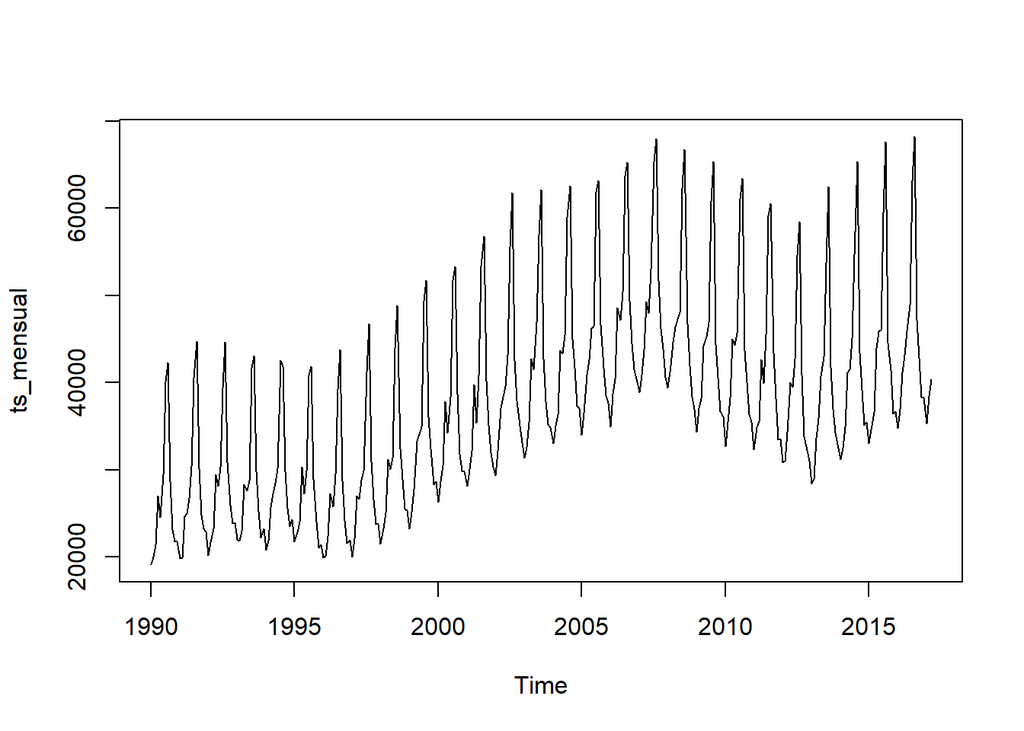

```r
# q1 <- autopista
# ts_mensual <- as_xts(q1, date_col = Mes_numeric)
ts_mensual <- ts(autopista$IMD_total, start=c(1990, 1), end=c(2017, 3), frequency=12)
plot(ts_mensual)
```

```r
summary(ts_mensual)
```

```
##    Min. 1st Qu.  Median    Mean 3rd Qu.    Max.
##   19110   29142   36706   37530   43718   68198
```

### Descomposición estacional

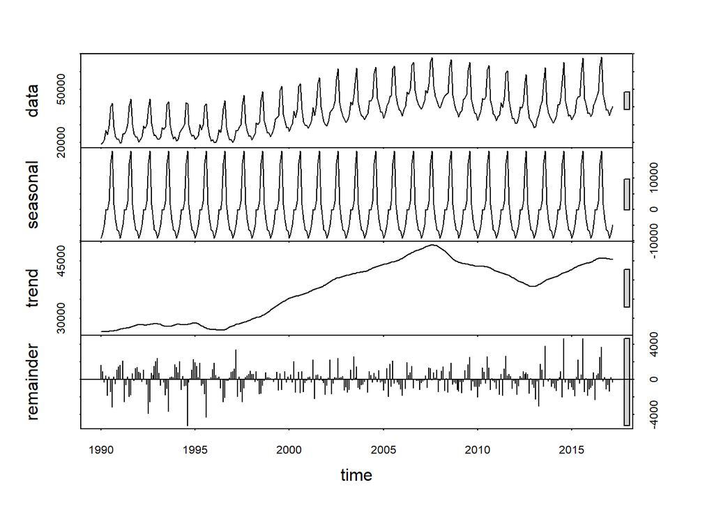

```r
fit <- stl(ts_mensual, s.window="period")
plot(fit)
```

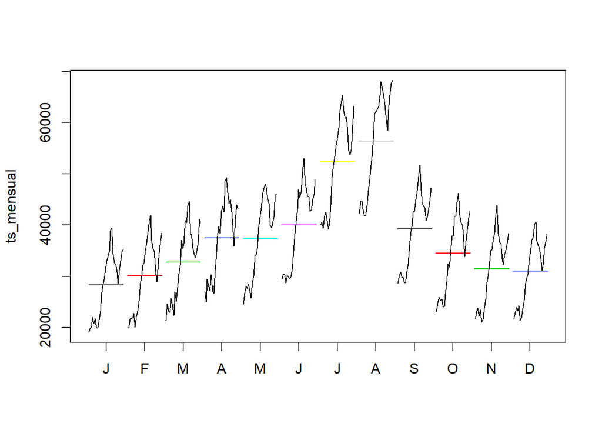

```r
monthplot(ts_mensual, col=1:12, pch=19)
```

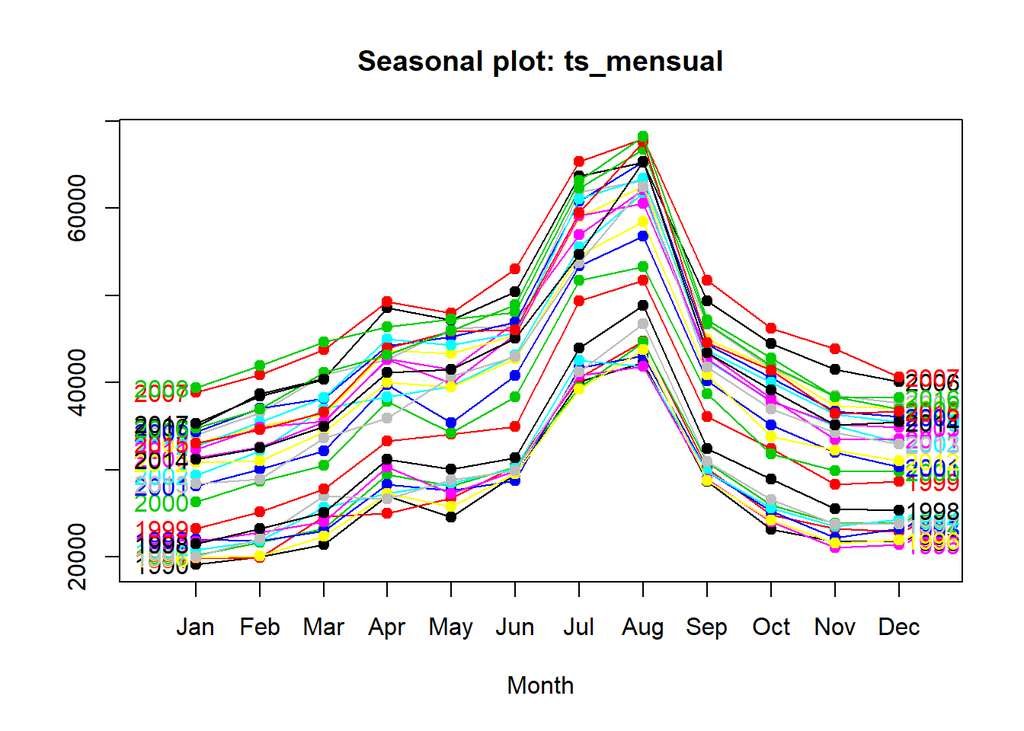

```r
seasonplot(ts_mensual, year.labels=TRUE, year.labels.left=TRUE, col=1:27, pch=19)
```

Seleccionar 1 ventana de la serie temporal para train y otra para test:

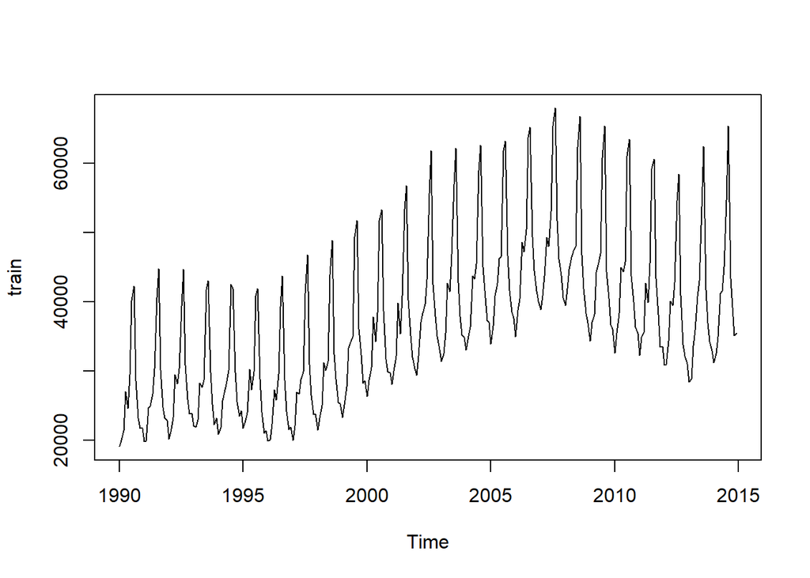

```r
train <- window(ts_mensual, start=c(1990, 01), end=c(2014, 12))
plot(train)
```

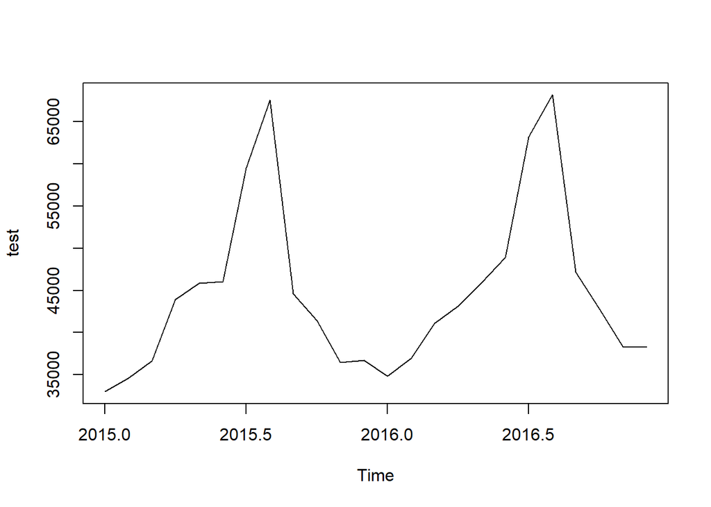

```r
test <- window(ts_mensual, start=c(2015, 01), end=c(2016, 12))
plot(test)
```

### Modelado exponencial ETS y predicción

```r
fit <- ets(train)
fit
```

```
## ETS(M,Ad,M)
##
## Call:
##  ets(y = train)
##
##   Smoothing parameters:
##     alpha = 0.2926
##     beta  = 0.0113
##     gamma = 0.1885
##     phi   = 0.976
##
##   Initial states:
##     l = 26017.4934
##     b = 130.5668
##     s=0.8186 0.8164 0.8964 1.0698 1.5608 1.4485
##            1.0647 0.9607 0.9981 0.8561 0.7682 0.7416
##
##   sigma:  0.0384
##
##      AIC     AICc      BIC
## 6074.223 6076.657 6140.891
```

```r
prediccion1 <- forecast(fit)
```

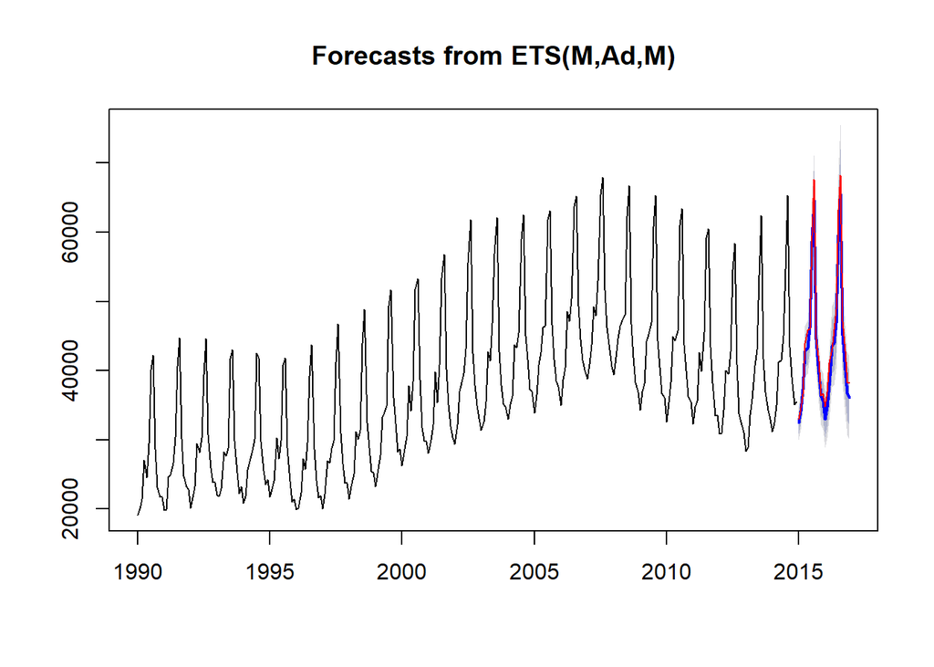

```r
par(mfrow=c(1,1))
plot(prediccion1)
lines(test, col="red")
```

Precisión:

```r
accuracy(prediccion1,test)
```

```
##                     ME     RMSE      MAE        MPE     MAPE      MASE
## Training set   -1.1779 1536.716 1137.553 0.07218132 3.013092 0.5936459
## Test set     1504.2500 1905.121 1605.455 3.27523085 3.529541 0.8378259
##                    ACF1 Theil's U
## Training set 0.09696071        NA
## Test set     0.06451700 0.2893606
```

### 4-Modelado ARIMA y predicción:

```r
fit2 <- auto.arima(train)
fit2
```

```
## Series: train
## ARIMA(2,1,0)(2,1,2)[12]
##
## Coefficients:
##           ar1      ar2     sar1     sar2    sma1     sma2
##       -0.7897  -0.2801  -0.5312  -0.1623  0.0369  -0.3680
## s.e.   0.0605   0.0591   0.1319   0.0973  0.1280   0.1049
##
## sigma^2 estimated as 1633281:  log likelihood=-2460.95
## AIC=4935.9   AICc=4936.31   BIC=4961.52
```

```r
prediccion2 <- forecast(fit2)
prediccion2
```

```
##          Point Forecast    Lo 80    Hi 80    Lo 95    Hi 95
## Jan 2015       32462.11 30824.28 34099.93 29957.27 34966.94
## Feb 2015       33914.56 32240.93 35588.20 31354.96 36474.17
## Mar 2015       36700.24 34796.58 38603.91 33788.84 39611.65
## Apr 2015       42621.25 40546.52 44695.99 39448.22 45794.28
## May 2015       42551.43 40351.27 44751.59 39186.58 45916.28
## Jun 2015       45537.82 43186.85 47888.80 41942.32 49133.33
## Jul 2015       56846.12 54369.61 59322.62 53058.63 60633.60
## Aug 2015       63873.22 61273.46 66472.98 59897.23 67849.21
## Sep 2015       43833.69 41115.06 46552.32 39675.90 47991.47
## Oct 2015       38660.76 35830.14 41491.39 34331.69 42989.83
## Nov 2015       35524.73 32585.25 38464.22 31029.18 40020.28
## Dec 2015       35144.42 32100.33 38188.50 30488.89 39799.94
## Jan 2016       32251.75 28803.81 35699.69 26978.58 37524.92
## Feb 2016       33593.81 30013.20 37174.42 28117.74 39069.88
## Mar 2016       36729.51 32937.03 40521.99 30929.41 42529.61
## Apr 2016       41518.80 37538.44 45499.16 35431.36 47606.24
## May 2016       42860.03 38713.65 47006.41 36518.69 49201.37
## Jun 2016       45923.01 41603.63 50242.39 39317.09 52528.93
## Jul 2016       57439.48 52960.52 61918.44 50589.51 64289.45
## Aug 2016       64162.37 59527.71 68797.04 57074.26 71250.48
## Sep 2016       44280.68 39494.86 49066.51 36961.39 51599.98
## Oct 2016       39285.05 34353.51 44216.58 31742.91 46827.18
## Nov 2016       36093.68 31020.12 41167.24 28334.35 43853.02
## Dec 2016       35402.66 30191.11 40614.20 27432.28 43373.03
```

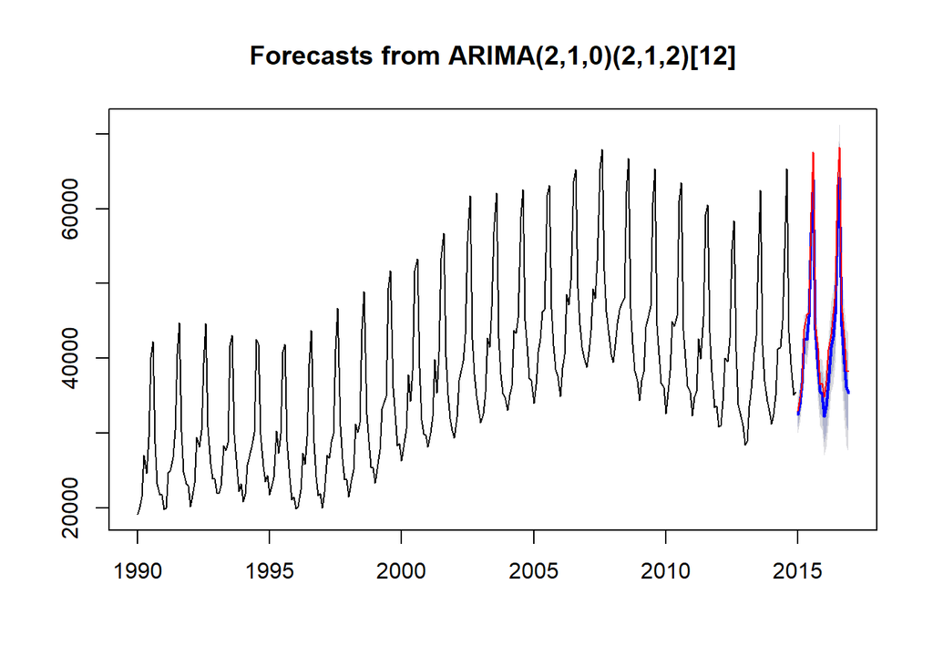

```r
plot(prediccion2)
lines(test, col="red")
```

Precisión:

```r
accuracy(prediccion2,test)
```

```
##                       ME     RMSE       MAE        MPE     MAPE      MASE
## Training set   -5.058141 1236.867  939.0563 -0.1128318 2.580322 0.4900578
## Test set     2414.450599 2795.501 2420.8877  5.2560467 5.273623 1.2633694
##                       ACF1 Theil's U
## Training set -0.0005854411        NA
## Test set      0.2960422184 0.4232369
```

Comparando con la anterior predice peor el de ARIMA (mayor RMSE).

```r
accuracy(prediccion1,test)
```

```
##                     ME     RMSE      MAE        MPE     MAPE      MASE
## Training set   -1.1779 1536.716 1137.553 0.07218132 3.013092 0.5936459
## Test set     1504.2500 1905.121 1605.455 3.27523085 3.529541 0.8378259
##                    ACF1 Theil's U
## Training set 0.09696071        NA
## Test set     0.06451700 0.2893606
```

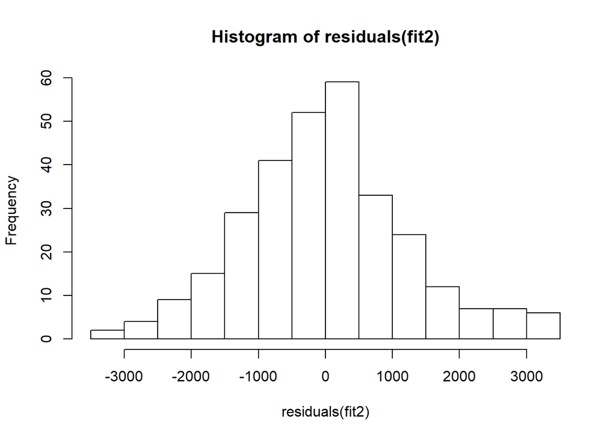

```r
hist(residuals(fit2))
```

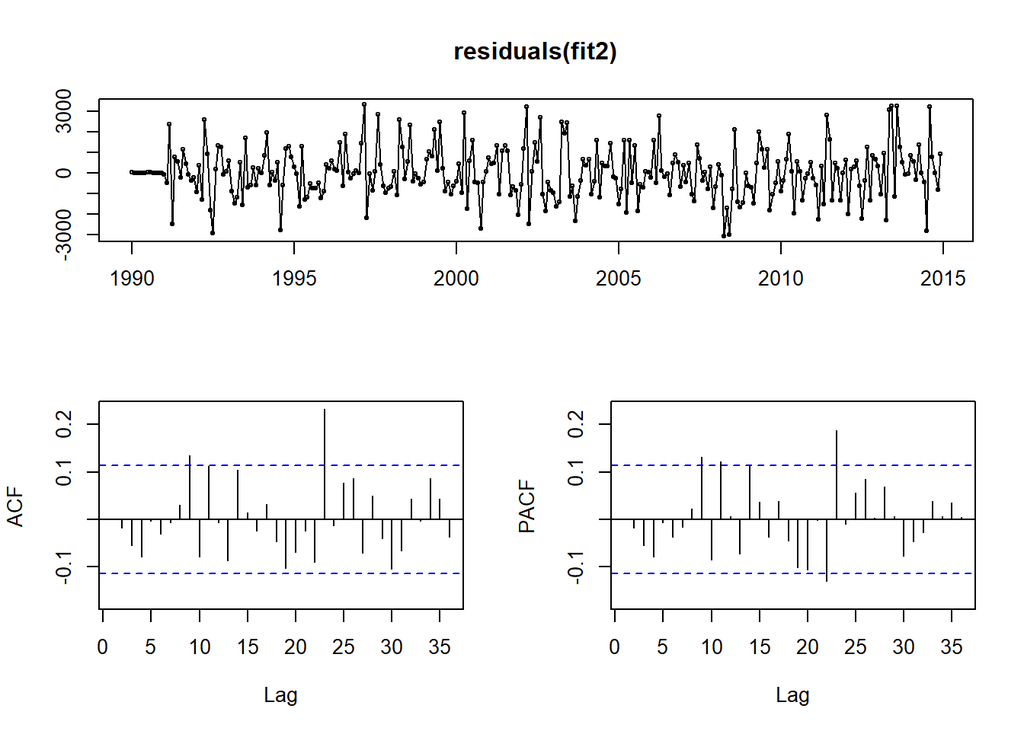

```r
tsdisplay(residuals(fit2))
```

```r
Box.test(residuals(fit2), type="Ljung")
```

```
##
##  Box-Ljung test
##
## data:  residuals(fit2)
## X-squared = 0.00010385, df = 1, p-value = 0.9919
```

## Voy a probar a hacer lo mismo pero aplicando primero log:

Creo serie temporal:

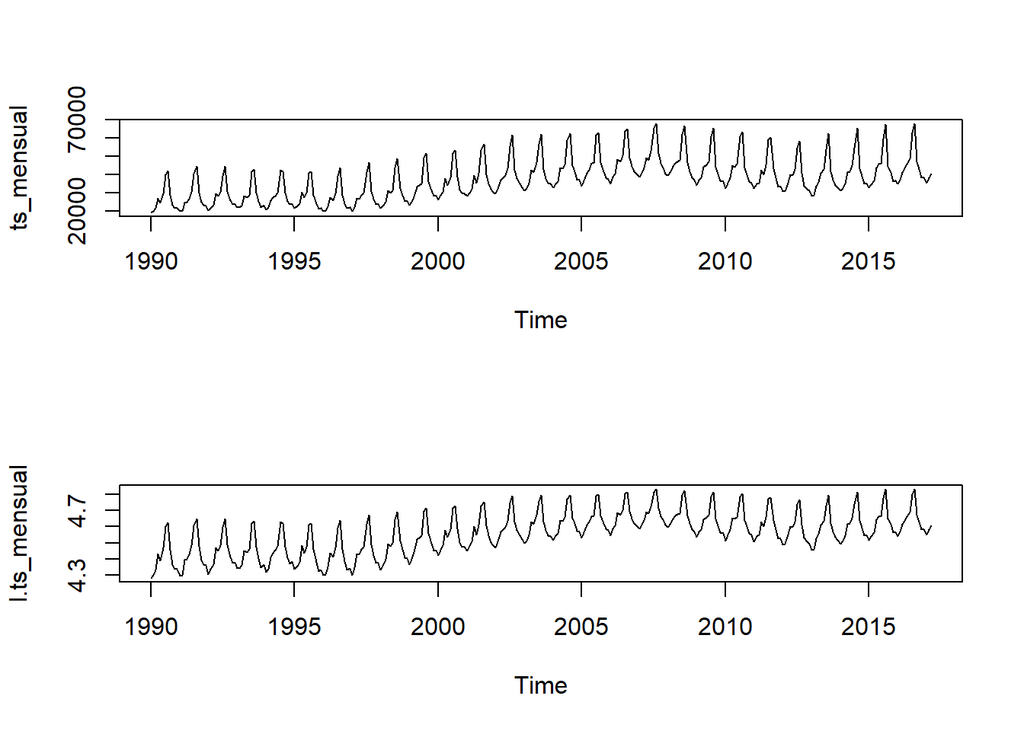

```r
l.ts_mensual <- log10(ts_mensual)
par(mfrow=c(2,1))
plot(ts_mensual)
plot(l.ts_mensual)
```

Summary:

```r
summary(l.ts_mensual)
```

```
##    Min. 1st Qu.  Median    Mean 3rd Qu.    Max.
##   4.281   4.464   4.565   4.555   4.641   4.834
```

### 2-B-Descomposición estacional:

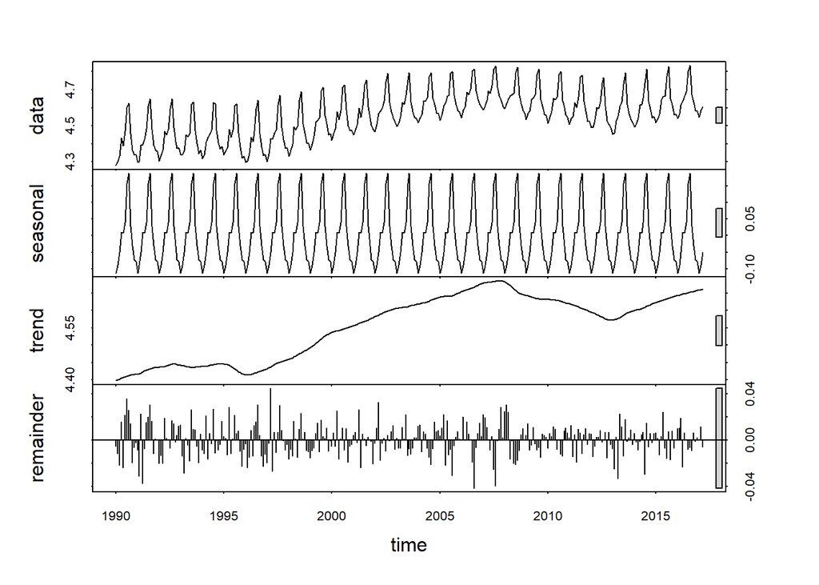

```r
fit <- stl(l.ts_mensual, s.window="period")
plot(fit)
```

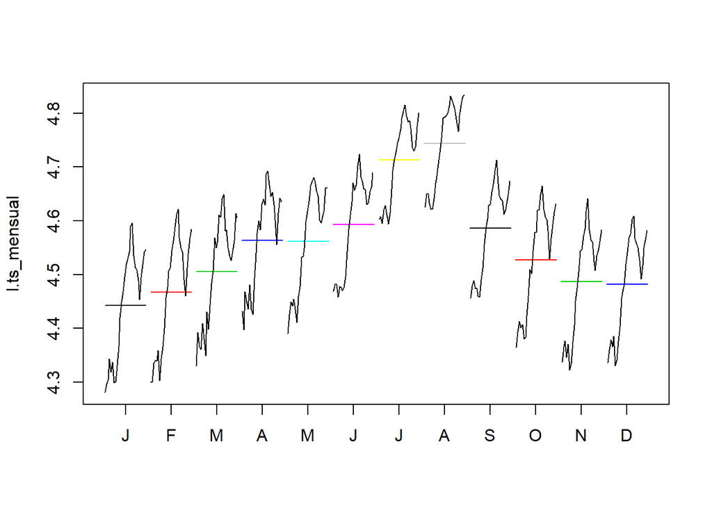

```r
monthplot(l.ts_mensual, col=1:12, pch=19)
```

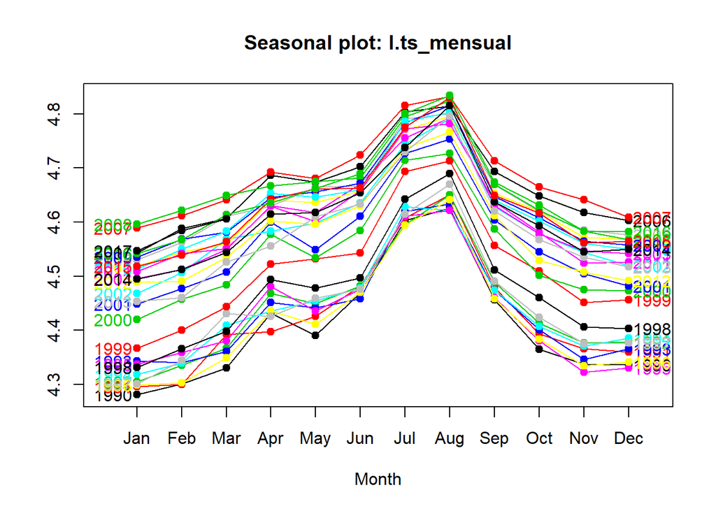

```r
seasonplot(l.ts_mensual, year.labels=TRUE, year.labels.left=TRUE, col=1:27, pch=19)
```

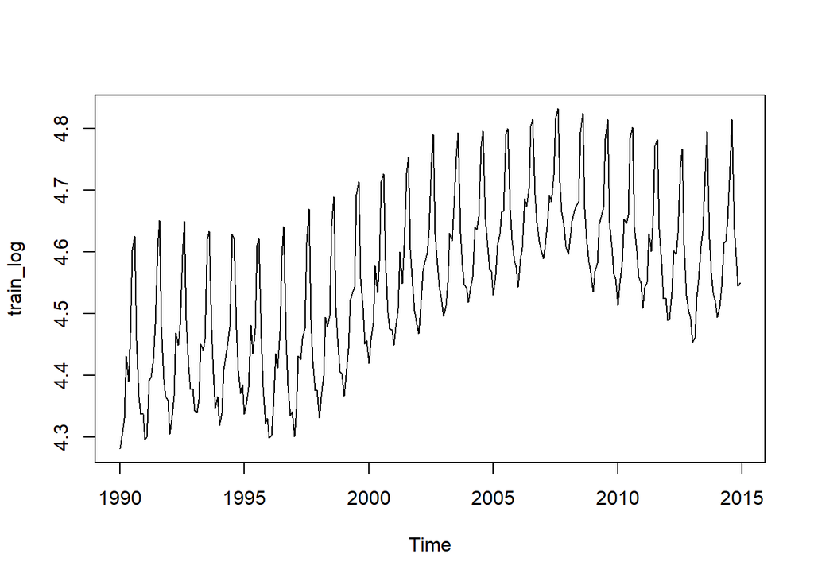

```r
train_log <- window(l.ts_mensual, start=c(1990, 01), end=c(2014, 12))
plot(train_log)
```

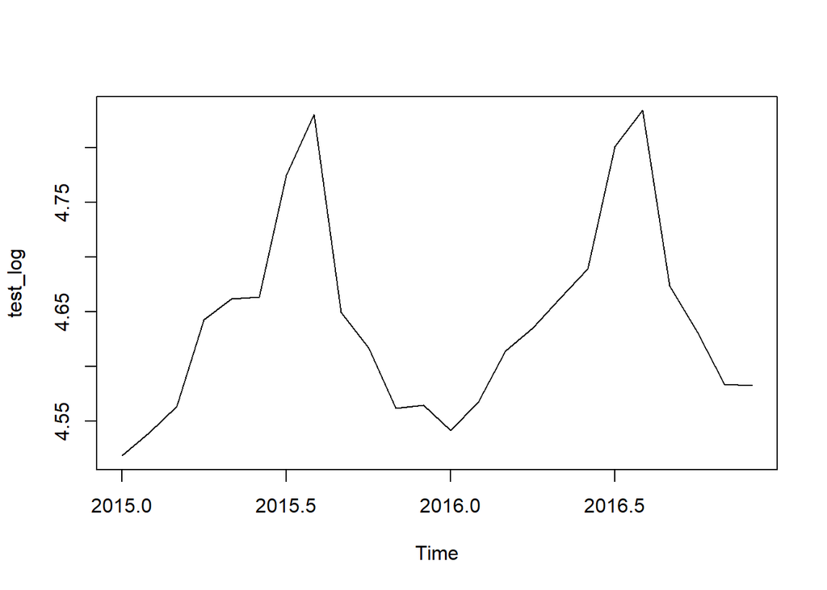

```r
test_log <- window(l.ts_mensual, start=c(2015, 01), end=c(2016, 12))
plot(test_log)
```

### 3-B-Modelado exponencial ETS y predicción

```r
fit_log <- ets(train_log)
fit_log
```

```
## ETS(M,A,A)
##
## Call:
##  ets(y = train_log)
##
##   Smoothing parameters:
##     alpha = 0.3089
##     beta  = 0.011
##     gamma = 0.1769
##
##   Initial states:
##     l = 4.4002
##     b = 0.0012
##     s=-0.0736 -0.0754 -0.0348 0.0417 0.2033 0.172
##            0.0402 -0.0045 0.0091 -0.0574 -0.1012 -0.1194
##
##   sigma:  0.0037
##
##       AIC      AICc       BIC
## -711.5616 -709.3914 -648.5973
```

```r
prediccion3 <- forecast(fit_log)
```

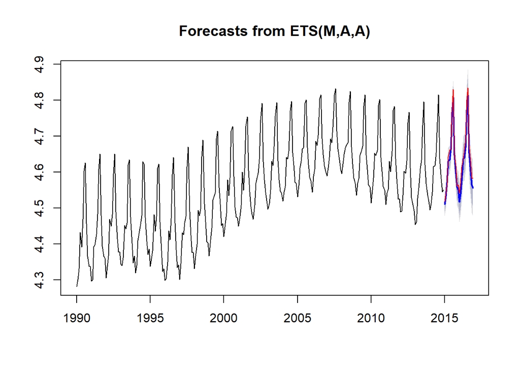

```r
par(mfrow=c(1,1))
plot(prediccion3)
lines(test_log, col="red")
```

Precisión:

```r
accuracy(prediccion3,test_log)
```

```
##                         ME       RMSE        MAE          MPE      MAPE
## Training set -0.0002081017 0.01671730 0.01289473 -0.004078701 0.2829641
## Test set      0.0164294131 0.01990976 0.01705506  0.353185039 0.3668677
##                   MASE       ACF1 Theil's U
## Training set 0.5465363 0.01288979        NA
## Test set     0.7228693 0.07647985 0.3023284
```

### 4-B-Modelado ARIMA y predicción:

```r
fit2_log <- auto.arima(train_log)
fit2_log
```

```
## Series: train_log
## ARIMA(2,1,0)(2,1,2)[12]
##
## Coefficients:
##           ar1      ar2     sar1     sar2    sma1     sma2
##       -0.7090  -0.2084  -0.7255  -0.2889  0.1706  -0.3636
## s.e.   0.0617   0.0599   0.1126   0.1054  0.1188   0.1140
##
## sigma^2 estimated as 0.0002529:  log likelihood=779.99
## AIC=-1545.97   AICc=-1545.57   BIC=-1520.36
```

```r
prediccion4 <- forecast(fit2_log)
prediccion4
```

```
##          Point Forecast    Lo 80    Hi 80    Lo 95    Hi 95
## Jan 2015       4.510733 4.490351 4.531116 4.479562 4.541905
## Feb 2015       4.527254 4.506027 4.548482 4.494789 4.559719
## Mar 2015       4.565765 4.541415 4.590115 4.528524 4.603005
## Apr 2015       4.632083 4.605490 4.658675 4.591413 4.672752
## May 2015       4.631815 4.603291 4.660339 4.588191 4.675438
## Jun 2015       4.659791 4.629277 4.690305 4.613124 4.706458
## Jul 2015       4.759786 4.727500 4.792071 4.710410 4.809162
## Aug 2015       4.809531 4.775536 4.843526 4.757540 4.861522
## Sep 2015       4.643156 4.607536 4.678777 4.588680 4.697633
## Oct 2015       4.583062 4.545891 4.620232 4.526214 4.639909
## Nov 2015       4.549090 4.510428 4.587751 4.489962 4.608218
## Dec 2015       4.541857 4.501761 4.581953 4.480535 4.603178
## Jan 2016       4.502877 4.458201 4.547552 4.434552 4.571202
## Feb 2016       4.519020 4.472416 4.565625 4.447745 4.590296
## Mar 2016       4.563391 4.514136 4.612646 4.488062 4.638720
## Apr 2016       4.614889 4.563286 4.666492 4.535970 4.693808
## May 2016       4.635757 4.581956 4.689558 4.553475 4.718038
## Jun 2016       4.667490 4.611513 4.723467 4.581881 4.753099
## Jul 2016       4.766765 4.708728 4.824801 4.678006 4.855524
## Aug 2016       4.818263 4.758226 4.878300 4.726444 4.910081
## Sep 2016       4.651278 4.589307 4.713250 4.556501 4.746056
## Oct 2016       4.596745 4.532898 4.660591 4.499100 4.694389
## Nov 2016       4.558727 4.493058 4.624396 4.458295 4.659159
## Dec 2016       4.549056 4.481615 4.616498 4.445914 4.652199
```

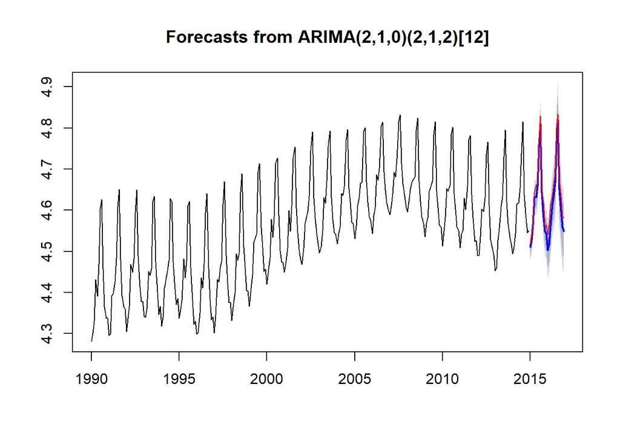

```r
plot(prediccion4)
lines(test_log, col="red")
```

Precisión:

```r
accuracy(prediccion4,test_log)
```

```
##                        ME       RMSE        MAE          MPE      MAPE
## Training set -0.000168393 0.01539243 0.01196204 -0.003595204 0.2628157
## Test set      0.022644597 0.02626477 0.02281216  0.488237250 0.4919088
##                   MASE        ACF1 Theil's U
## Training set 0.5070044 0.006313184        NA
## Test set     0.9668809 0.335468046 0.4010764
```

Ahora el RMSE es menor en test de ETS y en train de ARIMA.

```r
accuracy(prediccion3,test_log)
```

```
##                         ME       RMSE        MAE          MPE      MAPE
## Training set -0.0002081017 0.01671730 0.01289473 -0.004078701 0.2829641
## Test set      0.0164294131 0.01990976 0.01705506  0.353185039 0.3668677
##                   MASE       ACF1 Theil's U
## Training set 0.5465363 0.01288979        NA
## Test set     0.7228693 0.07647985 0.3023284
```

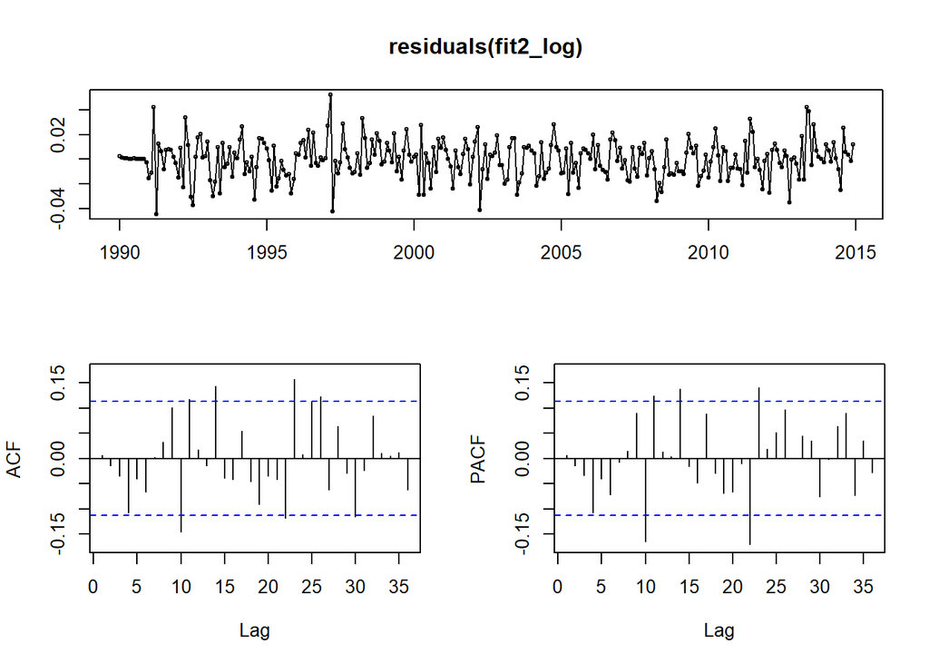

```r
tsdisplay(residuals(fit2_log))
```

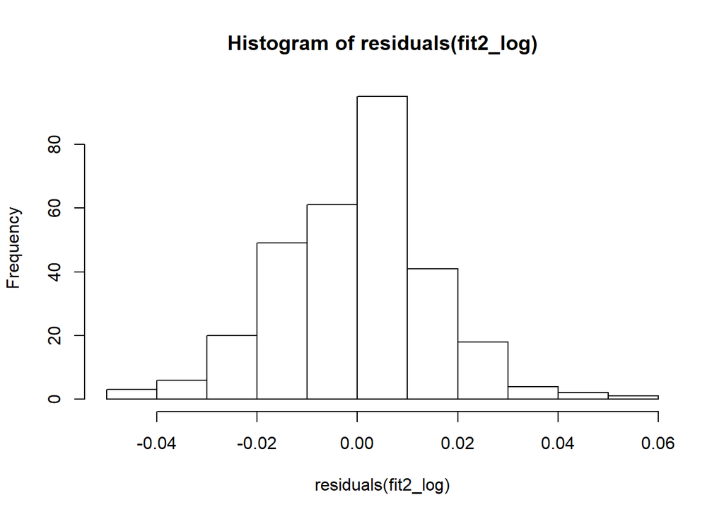

```r
hist(residuals(fit2_log))
```

```r
Box.test(residuals(fit2_log),  type="Ljung")
```

```
##
##  Box-Ljung test
##
## data:  residuals(fit2_log)
## X-squared = 0.012077, df = 1, p-value = 0.9125
```

## Resumen de las predicciones anteriores

Creo que de estas tablas sacaría la información para Shiny: Añadir valores reales

```r
#prediccion con ETS si aplicar log
tabla_shiny1 <- as.data.frame(prediccion1)
#prediccion con ARIMA si aplicar log
tabla_shiny2 <- as.data.frame(prediccion2)
#prediccion con ETS aplicando log
tabla_shiny3 <- as.data.frame(prediccion3)
#prediccion con ARIMA aplicando log
tabla_shiny4 <- as.data.frame(prediccion4)
```

Construyo una tabla comparativa con todos los modelos

```r
a <- as.data.frame(accuracy(prediccion1, test))[, 2:3]
a$modelo <- "ETS"
b <- as.data.frame(accuracy(prediccion2, test))[, 2:3]
b$modelo <- "ARIMA"
c <- as.data.frame(accuracy(prediccion3, test_log))[, 2:3]
c$modelo  <- "ETS_log"
d <- as.data.frame(accuracy(prediccion4, test_log))[, 2:3]
d$modelo <- "ARIMA_log"
compara_predicciones_modelos <- rbind(a, b, c, d)
kable(compara_predicciones_modelos)
```

|  | RMSE | MAE | modelo |
| --- | --- | --- | --- |
| Training set | 1536.7162051 | 1137.5533844 | ETS |
| Test set | 1905.1211700 | 1605.4547315 | ETS |
| Training set1 | 1236.8669015 | 939.0562684 | ARIMA |
| Test set1 | 2795.5006487 | 2420.8876501 | ARIMA |
| Training set2 | 0.0167173 | 0.0128947 | ETS_log |
| Test set2 | 0.0199098 | 0.0170551 | ETS_log |
| Training set3 | 0.0153924 | 0.0119620 | ARIMA_log |
| Test set3 | 0.0262648 | 0.0228122 | ARIMA_log |